# KNN_PROB_CODE_ML_GRP_76_ASS_2

#### PROBLEM STATEMENT for K-NN:

##### TYPE 1 (WITH FULL FEATURES)

###### The given dataset is composed of a range of biomedical voice measurements from 31 people, 23 with Parkinson's disease (PD). Each column in the table is a particular voice measure, and each row corresponds one of 195 voice recording from these individuals ("name" column). The main aim of the data is to discriminate healthy people from those with Parkinson's Disease, according to "status" column which is set to 0 for healthy and 1 for PD. Dataset can be downloaded from below link.

###### https://archive.ics.uci.edu/ml/datasets/parkinsons

###### Create classification model using KNN. Identify the optimum no of neighbors and dimensions for your model.

###### Justify if KNN model should be considered or not for the problem statement.

##### Evaluation will be based on..

###### 1) Handling of missing values, outliers, if any .

###### 2) Identifying data and model issues if any.

###### 3) Choice of packages and distance measure used. justify your answer.

###### 4) Selection of train, test split.

###### 5) Final model creation and accuracy matrix selected for the model.

###### 6) Future scope of the work.

##### * Included Required Library

```python
import os
import numpy as np
import matplotlib.pyplot as plt
import pandas as pd
import seaborn as sns
```

##### * Importing data sets from Excel or Direct URL

```python
##path="https://archive.ics.uci.edu/ml/machine-learning-databases/parkinsons/parkinsons.data"
PAR_FOLDER=os.getcwd()
print(PAR_FOLDER)
input_data_file=os.path.join(PAR_FOLDER, 'parkinsons.csv')
dataset = pd.read_csv(input_data_file)
```

```
C:\Users\kdevanand\ML\Assignment2
```

##### * Display of dataset Head and Info

```python
display(dataset.head())
display(dataset.info())
```

|  | name | MDVP:Fo(Hz) | MDVP:Fhi(Hz) | MDVP:Flo(Hz) | MDVP:Jitter(%) | MDVP:Jitter(Abs) | MDVP:RAP | MDVP:PPQ | Jitter:DDP | MDVP:Shimmer | ... | Shimmer:DDA | NHR | HNR | status | RPDE | DFA | spread1 | spread2 | D2 | PPE |
| --- | --- | --- | --- | --- | --- | --- | --- | --- | --- | --- | --- | --- | --- | --- | --- | --- | --- | --- | --- | --- | --- |
| 0 | phon_R01_S01_1 | 119.992 | 157.302 | 74.997 | 0.00784 | 0.00007 | 0.00370 | 0.00554 | 0.01109 | 0.04374 | ... | 0.06545 | 0.02211 | 21.033 | 1 | 0.414783 | 0.815285 | -4.813031 | 0.266482 | 2.301442 | 0.284654 |
| 1 | phon_R01_S01_2 | 122.400 | 148.650 | 113.819 | 0.00968 | 0.00008 | 0.00465 | 0.00696 | 0.01394 | 0.06134 | ... | 0.09403 | 0.01929 | 19.085 | 1 | 0.458359 | 0.819521 | -4.075192 | 0.335590 | 2.486855 | 0.368674 |
| 2 | phon_R01_S01_3 | 116.682 | 131.111 | 111.555 | 0.01050 | 0.00009 | 0.00544 | 0.00781 | 0.01633 | 0.05233 | ... | 0.08270 | 0.01309 | 20.651 | 1 | 0.429895 | 0.825288 | -4.443179 | 0.311173 | 2.342259 | 0.332634 |
| 3 | phon_R01_S01_4 | 116.676 | 137.871 | 111.366 | 0.00997 | 0.00009 | 0.00502 | 0.00698 | 0.01505 | 0.05492 | ... | 0.08771 | 0.01353 | 20.644 | 1 | 0.434969 | 0.819235 | -4.117501 | 0.334147 | 2.405554 | 0.368975 |
| 4 | phon_R01_S01_5 | 116.014 | 141.781 | 110.655 | 0.01284 | 0.00011 | 0.00655 | 0.00908 | 0.01966 | 0.06425 | ... | 0.10470 | 0.01767 | 19.649 | 1 | 0.417356 | 0.823484 | -3.747787 | 0.234513 | 2.332180 | 0.410335 |

5 rows × 24 columns

```
<class 'pandas.core.frame.DataFrame'>
RangeIndex: 195 entries, 0 to 194
Data columns (total 24 columns):
 #   Column            Non-Null Count  Dtype
---  ------            --------------  -----
 0   name              195 non-null    object
 1   MDVP:Fo(Hz)       195 non-null    float64
 2   MDVP:Fhi(Hz)      195 non-null    float64
 3   MDVP:Flo(Hz)      195 non-null    float64
 4   MDVP:Jitter(%)    195 non-null    float64
 5   MDVP:Jitter(Abs)  195 non-null    float64
 6   MDVP:RAP          195 non-null    float64
 7   MDVP:PPQ          195 non-null    float64
 8   Jitter:DDP        195 non-null    float64
 9   MDVP:Shimmer      195 non-null    float64
```

[output cut: 16 more lines]

```
None
```

```python
dataset.isnull().sum()
```

```
name                0
MDVP:Fo(Hz)         0
MDVP:Fhi(Hz)        0
MDVP:Flo(Hz)        0
MDVP:Jitter(%)      0
MDVP:Jitter(Abs)    0
MDVP:RAP            0
MDVP:PPQ            0
Jitter:DDP          0
MDVP:Shimmer        0
MDVP:Shimmer(dB)    0
Shimmer:APQ3        0
Shimmer:APQ5        0
MDVP:APQ            0
Shimmer:DDA         0
NHR                 0
HNR                 0
status              0
RPDE                0
DFA                 0
spread1             0
spread2             0
D2                  0
PPE                 0
dtype: int64
```

```python
print("No Null Value found : ",dataset.isnull().sum().values.any())
print("Total Null Value : ", dataset.isnull().sum().sum())
```

```
No Null Value found :  False
Total Null Value :  0
```

##### * So, from above dataset, we don't have missing values

##### * Heat map of Dataset

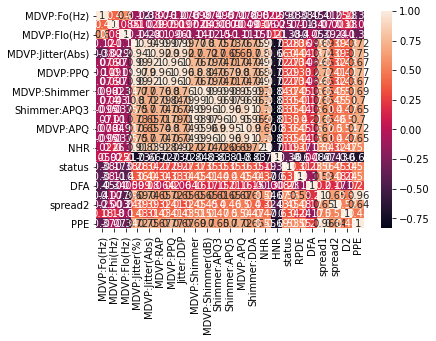

```python
sns.heatmap(dataset.corr(), annot=True)
```

##### * Box plot and Outliers

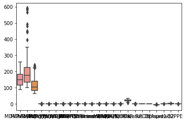

```python
sns.boxplot(data=dataset)
```

##### * Box plot without Outliers

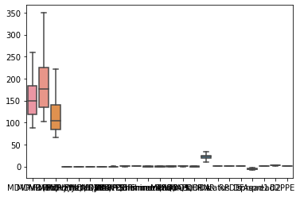

```python
sns.boxplot(data=dataset, showfliers=False)
```

##### * Selecting Features and Labels

```python
features=dataset.loc[:,dataset.columns!='status'].values[:,1:]
display(features)
labels=dataset.loc[:,'status'].values
display(labels)
```

```
array([[119.992, 157.302, 74.997, ..., 0.266482, 2.301442, 0.284654],
       [122.4, 148.65, 113.819, ..., 0.33559, 2.486855, 0.368674],
       [116.682, 131.111, 111.555, ..., 0.311173, 2.342259, 0.332634],
       ...,
       [174.688, 240.005, 74.287, ..., 0.158453, 2.679772, 0.131728],
       [198.764, 396.961, 74.904, ..., 0.207454, 2.138608, 0.123306],
       [214.289, 260.277, 77.973, ..., 0.190667, 2.555477, 0.148569]],
      dtype=object)
```

```
array([1, 1, 1, 1, 1, 1, 1, 1, 1, 1, 1, 1, 1, 1, 1, 1, 1, 1, 1, 1, 1, 1,
       1, 1, 1, 1, 1, 1, 1, 1, 0, 0, 0, 0, 0, 0, 1, 1, 1, 1, 1, 1, 0, 0,
       0, 0, 0, 0, 0, 0, 0, 0, 0, 0, 1, 1, 1, 1, 1, 1, 0, 0, 0, 0, 0, 0,
       1, 1, 1, 1, 1, 1, 1, 1, 1, 1, 1, 1, 1, 1, 1, 1, 1, 1, 1, 1, 1, 1,
       1, 1, 1, 1, 1, 1, 1, 1, 1, 1, 1, 1, 1, 1, 1, 1, 1, 1, 1, 1, 1, 1,
       1, 1, 1, 1, 1, 1, 1, 1, 1, 1, 1, 1, 1, 1, 1, 1, 1, 1, 1, 1, 1, 1,
       1, 1, 1, 1, 1, 1, 1, 1, 1, 1, 1, 1, 1, 1, 1, 1, 1, 1, 1, 1, 1, 1,
       1, 1, 1, 1, 1, 1, 1, 1, 1, 1, 1, 0, 0, 0, 0, 0, 0, 0, 0, 0, 0, 0,
       0, 1, 1, 1, 1, 1, 1, 0, 0, 0, 0, 0, 0, 0, 0, 0, 0, 0, 0],
      dtype=int64)
```

##### * Display of Parkinson's and Non Parkinson's patient

```python
print("Parkinson's Patient =",labels[labels==1].shape[0])
print("Not Parkinson's Patient =",labels[labels==0].shape[0])
```

```
Parkinson's Patient = 147
Not Parkinson's Patient = 48
```

##### 3) Choice of packages and distance measure used. justify your answer.

###### Following packages has used as per given reason:

###### 1. train_test_split for splitting train and test data

###### 2. StandardScaler for scalling of train and test data

###### 3. NearestNeighbors for neighbors distance calculation

###### 4. KNeighborsClassifier for KNN classification

###### 5. classification_report, confusion_matrix, accuracy_score

##### * Splitting Training and Test data in ratio of 70% and 30%

##### 4) Selection of train, test split.

```python
from sklearn.model_selection import train_test_split
X_train, X_test, y_train, y_test = train_test_split(features, labels, test_size = 0.30, random_state=1)
print("Training Data =", (X_train).shape[0], (y_train).shape[0])
print("Test Data =", (X_test).shape[0], (y_test).shape[0])
```

```
Training Data = 136 136
Test Data = 59 59
```

##### * Since Data values are in different units and having very high and low values compairing to features, so have done standard scalling to bring in same unit and satndard level.

```python
from sklearn.preprocessing import StandardScaler
scaler = StandardScaler()
scaler.fit(X_train)
X_train = scaler.transform(X_train)
X_test = scaler.transform(X_test)
print(X_test)
```

```
[[-0.82632799 -0.76962193 -0.75190626 ...  0.35062367  0.31331705
   0.23804964]
 [-0.20992416  1.93534894 -0.8475211  ...  0.17092931 -0.33253515
   0.08349025]
 [ 0.00733293 -0.15852061 -1.18294393 ...  1.57224866  1.83341735
   1.83613543]
 ...
 [ 1.12864243  2.51126871 -1.03395936 ... -0.21242655 -0.65541893
  -0.96038265]
 [ 1.09933308  0.34611849 -0.65705046 ... -0.72172865  1.25234812
  -0.08471483]
 [-0.99904468  4.82399067 -0.2720768  ...  0.96436087 -1.19375947
   0.1637907 ]]
```

```python
from sklearn.neighbors import NearestNeighbors
neigh = NearestNeighbors(n_neighbors=3)
neigh.fit(X_test)
display(neigh.kneighbors([[168.778,232.181,75.603,0.00718,0.00004,0.00284,0.00387,0.00853,0.03327,0.348,0.01441,0.01893,0.0343,0.04322,0.02919,20.376,0.631099,0.605417,-2.93107,0.434326,3.007463,0.430788]]))
```

```
(array([[294.4396896 , 294.51816033, 294.68744846]]),
 array([[58, 38, 29]], dtype=int64))
```

##### 5) Final model creation and accuracy matrix selected for the model.

```python
from sklearn.neighbors import KNeighborsClassifier
classifier = KNeighborsClassifier(n_neighbors = 3)
classifier.fit(X_train, y_train)
y_pred = classifier.predict(X_test)
print(y_pred)
predicted= classifier.predict([[168.778, 232.181, 75.603, 0.00718, 0.00004, 0.00284, 0.00387, 0.00853, 0.03327, 0.348, 0.01441, 0.01893, 0.0343, 0.04322, 0.02919, 20.376, 0.631099, 0.605417, -2.93107, 0.434326, 3.007463, 0.430788]])
print(predicted)
```

```
[1 1 1 0 1 1 1 1 0 1 1 0 1 1 1 0 1 1 1 1 1 1 1 1 1 1 1 1 1 0 1 1 1 1 1 1 0
 1 1 0 1 1 1 0 1 1 1 1 1 1 0 0 1 1 1 1 0 1 1]
[1]
```

##### * Scatter plot of test data

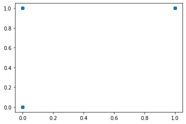

```python
plt.scatter(y_test, y_pred)
plt.show()
```

##### 5) Final model creation and accuracy matrix selected for the model.

```python
from sklearn.metrics import classification_report, confusion_matrix, accuracy_score
result = confusion_matrix(y_test, y_pred)
print("Confusion Matrix:")
print(result)
result1 = classification_report(y_test, y_pred)
print("Classification Report:",)
print (result1)
result2 = accuracy_score(y_test,y_pred)
print("Accuracy:",result2)
```

```
Confusion Matrix:
[[11  8]
 [ 0 40]]
Classification Report:
              precision    recall  f1-score   support

           0       1.00      0.58      0.73        19
           1       0.83      1.00      0.91        40

    accuracy                           0.86        59
   macro avg       0.92      0.79      0.82        59
weighted avg       0.89      0.86      0.85        59

Accuracy: 0.864406779661017
```

##### * Dropped following features of data, which doesn't impact much on patient status determination

```python
dataset = dataset.drop(columns=["MDVP:Jitter(Abs)", "MDVP:RAP","MDVP:PPQ","Jitter:DDP", "MDVP:Shimmer(dB)","Shimmer:APQ3","Shimmer:APQ5","MDVP:APQ","Shimmer:DDA","spread1","spread2","D2"])
dataset.info()
```

```
<class 'pandas.core.frame.DataFrame'>
RangeIndex: 195 entries, 0 to 194
Data columns (total 12 columns):
 #   Column          Non-Null Count  Dtype
---  ------          --------------  -----
 0   name            195 non-null    object
 1   MDVP:Fo(Hz)     195 non-null    float64
 2   MDVP:Fhi(Hz)    195 non-null    float64
 3   MDVP:Flo(Hz)    195 non-null    float64
 4   MDVP:Jitter(%)  195 non-null    float64
 5   MDVP:Shimmer    195 non-null    float64
 6   NHR             195 non-null    float64
 7   HNR             195 non-null    float64
 8   status          195 non-null    int64
 9   RPDE            195 non-null    float64
 10  DFA             195 non-null    float64
 11  PPE             195 non-null    float64
dtypes: float64(10), int64(1), object(1)
memory usage: 18.4+ KB
```

##### * Histogram of dataset fetures

```
array([[<matplotlib.axes._subplots.AxesSubplot object at 0x0000027F446D1850>,
      dtype=object)
```

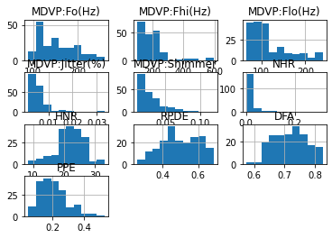

```python
dataset.hist(column=["MDVP:Fo(Hz)","MDVP:Fhi(Hz)","MDVP:Flo(Hz)","MDVP:Jitter(%)","MDVP:Shimmer","NHR","HNR","RPDE","DFA","PPE"])
```

##### Heat map of Dataset

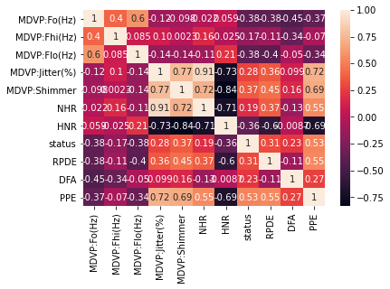

```python
sns.heatmap(dataset.corr(), annot=True)
```

##### 1) Handling of missing values, outliers, if any

```python
dataset.isnull().sum()
```

```
name              0
MDVP:Fo(Hz)       0
MDVP:Fhi(Hz)      0
MDVP:Flo(Hz)      0
MDVP:Jitter(%)    0
MDVP:Shimmer      0
NHR               0
HNR               0
status            0
RPDE              0
DFA               0
PPE               0
dtype: int64
```

```python
print("No Null Value found : ",dataset.isnull().sum().values.any())
print("Total Null Value : ", dataset.isnull().sum().sum())
```

```
No Null Value found :  False
Total Null Value :  0
```

##### * Box plot and Outliers

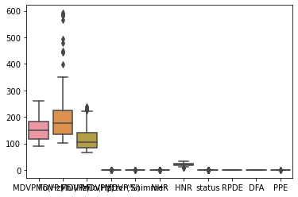

```python
sns.boxplot(data=dataset)
```

##### * Box plot Without Outliers

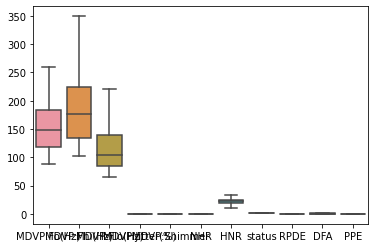

```python
sns.boxplot(data=dataset, showfliers=False)
```

##### * Selecting Features and Labels

```python
features=dataset.loc[:,dataset.columns!='status'].values[:,1:]
display(features)
labels=dataset.loc[:,'status'].values
display(labels)
```

```
array([[119.992, 157.302, 74.997, ..., 0.414783, 0.815285, 0.284654],
       [122.4, 148.65, 113.819, ..., 0.458359, 0.819521, 0.368674],
       [116.682, 131.111, 111.555, ..., 0.429895, 0.825288, 0.332634],
       ...,
       [174.688, 240.005, 74.287, ..., 0.407567, 0.655683, 0.131728],
       [198.764, 396.961, 74.904, ..., 0.451221, 0.643956, 0.123306],
       [214.289, 260.277, 77.973, ..., 0.462803, 0.664357, 0.148569]],
      dtype=object)
```

```
array([1, 1, 1, 1, 1, 1, 1, 1, 1, 1, 1, 1, 1, 1, 1, 1, 1, 1, 1, 1, 1, 1,
       1, 1, 1, 1, 1, 1, 1, 1, 0, 0, 0, 0, 0, 0, 1, 1, 1, 1, 1, 1, 0, 0,
       0, 0, 0, 0, 0, 0, 0, 0, 0, 0, 1, 1, 1, 1, 1, 1, 0, 0, 0, 0, 0, 0,
       1, 1, 1, 1, 1, 1, 1, 1, 1, 1, 1, 1, 1, 1, 1, 1, 1, 1, 1, 1, 1, 1,
       1, 1, 1, 1, 1, 1, 1, 1, 1, 1, 1, 1, 1, 1, 1, 1, 1, 1, 1, 1, 1, 1,
       1, 1, 1, 1, 1, 1, 1, 1, 1, 1, 1, 1, 1, 1, 1, 1, 1, 1, 1, 1, 1, 1,
       1, 1, 1, 1, 1, 1, 1, 1, 1, 1, 1, 1, 1, 1, 1, 1, 1, 1, 1, 1, 1, 1,
       1, 1, 1, 1, 1, 1, 1, 1, 1, 1, 1, 0, 0, 0, 0, 0, 0, 0, 0, 0, 0, 0,
       0, 1, 1, 1, 1, 1, 1, 0, 0, 0, 0, 0, 0, 0, 0, 0, 0, 0, 0],
      dtype=int64)
```

##### * Display of Parkinson's and Non Parkinson's patient

```python
print("Parkinson's Patient =",labels[labels==1].shape[0])
print("Not Parkinson's Patient =",labels[labels==0].shape[0])
```

```
Parkinson's Patient = 147
Not Parkinson's Patient = 48
```

##### 3) Choice of packages and distance measure used. justify your answer.

###### Following packages has used as per given reason:

###### 1. train_test_split for splitting train and test data

###### 2. StandardScaler for scalling of train and test data

###### 3. NearestNeighbors for neighbors distance calculation

###### 4. KNeighborsClassifier for KNN classification

###### 5. classification_report, confusion_matrix, accuracy_score

##### * Splitting Training and Test data in ratio of 70% and 30%

##### 4) Selection of train, test split.

```python
from sklearn.model_selection import train_test_split
X_train, X_test, y_train, y_test = train_test_split(features, labels, test_size = 0.30, random_state=1)
print("Training Data =", (X_train).shape[0], (y_train).shape[0])
print("Test Data =", (X_test).shape[0], (y_test).shape[0])
```

```
Training Data = 136 136
Test Data = 59 59
```

##### * Since Data values are in different units and having very high and low values compairing to features, so have done standard scalling to bring in same unit and satndard level.

```python
from sklearn.preprocessing import StandardScaler
scaler = StandardScaler()
scaler.fit(X_train)
X_train = scaler.transform(X_train)
X_test = scaler.transform(X_test)
print(X_test)
```

[output not shown]

[output cut: 122 more lines]

[output not shown]

```python
from sklearn.neighbors import NearestNeighbors
neigh = NearestNeighbors(n_neighbors=3)
neigh.fit(X_test)
display(neigh.kneighbors([[119.992,157.302,74.997,0.00784,0.04374,0.02211,21.033,0.414783,0.815285,0.284654]]))
```

```
(array([[209.51689444, 209.62584308, 209.69728284]]),
 array([[29, 11, 58]], dtype=int64))
```

##### 5) Final model creation and accuracy matrix selected for the model.

```python
from sklearn.neighbors import KNeighborsClassifier
classifier = KNeighborsClassifier(n_neighbors = 3)
classifier.fit(X_train, y_train)
y_pred = classifier.predict(X_test)
print(y_pred)
predicted= classifier.predict([[119.992,157.302,74.997,0.00784,0.04374,0.02211,21.033,0.414783,0.815285,0.284654]])
print(predicted)
```

```
[1 1 1 0 1 1 1 1 0 1 1 0 1 1 1 0 1 1 1 1 0 1 1 1 1 1 1 1 1 0 1 1 1 1 1 1 0
 1 1 0 1 1 1 0 1 1 1 1 1 1 0 0 1 1 0 0 0 1 1]
[0]
```

##### * Scatter plot of test data

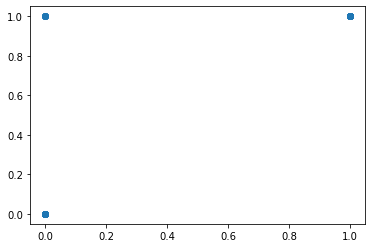

```python
plt.scatter(y_test, y_pred)
plt.show()
```

###### 5) Final model creation and accuracy matrix selected for the model.

```python
from sklearn.metrics import classification_report, confusion_matrix, accuracy_score
result = confusion_matrix(y_test, y_pred)
print("Confusion Matrix:")
print(result)
result1 = classification_report(y_test, y_pred)
print("Classification Report:",)
print (result1)
result2 = accuracy_score(y_test,y_pred)
print("Accuracy:",result2)
```

```
Confusion Matrix:
[[14  5]
 [ 0 40]]
Classification Report:
              precision    recall  f1-score   support

           0       1.00      0.74      0.85        19
           1       0.89      1.00      0.94        40

    accuracy                           0.92        59
   macro avg       0.94      0.87      0.89        59
weighted avg       0.92      0.92      0.91        59

Accuracy: 0.9152542372881356
```

##### TOTAL ACCURACY OF MODEL = 91.52%

##### CONCLUSItON : Reduced features count has increased efficiency of 91.52% whereas including total features has reduced efficiency of = 86.44%

##### 6) Future scope of the work

###### The current prediction level is 91.52% and is very good. Any further fitting will be overfitting the model and may make the model to be not a good use. We can use this for further prediction until we see predicted output is becoming false in more cases. On the contrary, being a medical field, we can aim to increase a fitting a bit more and use it occasionally when we have reasonable doubt from other indications.

###### Although we have used a dataset of 195 instances, the accuracy of our approach can be further improved by implementing it on a larger dataset, having more number of instances of each severity class as well as on a combined database of patients’ patient attributes and features. Using other models like ensemble techniques to further understand and improve the accuracy of the models compared to classification models. The ensemble techniques like xgboost, bagging classifier give more accurate predictions. Further studies can be done using ensemble techniques to understand if we can improve accuracy on the training set to 100%.